# Wine reviews

mdneuzerling

30 June, 2018

## Incomplete data

From the data visualisation below, we can see that the price data for the wine is incomplete. Approximately 7% of the price values are missing. The other missing values are actually empty strings. Interestingly, a data frame doesn’t treat these as missing by default, but a tibble does.

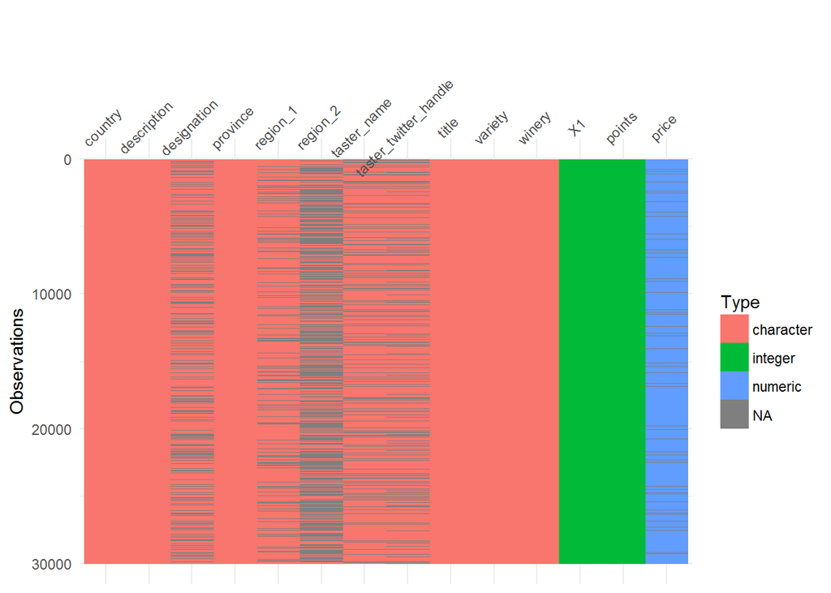

```r
wine %>% sample_n(30000) %>% vis_dat
```

One wine, indexed 86909, has a missing variety. Fortunately, we can recover the information from the review:

```r
wine <- wine %>% mutate(
  variety = ifelse(X1 == 86909, "petite syrah", variety)
)
```

Petite Syrah

## Grape colours

In order to classify the wines as red, white or rosé, we’re going to scrape wine data from the [List of grape varieties](https://en.wikipedia.org/wiki/List_of_grape_varieties) Wikipedia page, using the `rvest` package. The first three tables of this page give red, white and rosé wines, in that order.

```r
wiki_tables <- "https://en.wikipedia.org/wiki/List_of_grape_varieties" %>%
    read_html %>%
    html_nodes("table")
red_wines <- wiki_tables[[1]] %>% html_table %>% cbind(colour = "red")
white_wines <- wiki_tables[[2]] %>% html_table %>% cbind(colour = "white")
rose_wines <- wiki_tables[[3]] %>% html_table %>% cbind(colour = "rosé")
all_wines <- rbind(red_wines, white_wines, rose_wines)
```

We’re interested in three columns here: `Common Name(s)`, `All Synonyms` and the `colour` column we defined from the table scraping. We will take the opportunity to rename the columns to match the tidyverse style.

Apart from synonyms, some wines can also have multiple common names, eg. “shiraz / syrah”. The synonyms seem to be very broad, and can include some unexpected results: pinot grigio (also known as pinot gris) is used to produce white wine, yet it appears as a synonym to canari noir, which is used to make red wine.

We’re going to preference the common names over the synonyms, so that in any conflict we use the colour as given by the common name. To do this, we’re going to `unnest` the common names and clean the results so that all entries are in lower-case, the results are distinct, and certain stray bits of punctuation are removed. We’re then going to do the same with the synonyms, but when we combine the results we will ignore all entries that are already provided by the common names.

The end result will be a single table with two columns: `variety`, and `colour`. The table may very well still contain duplicates, but certainly less than we would have had if we had treated common names and synonyms as equals.

```r
all_wines_cleaned <- all_wines %>%
    rename(
        common_names = `Common Name(s)`,
        synonyms = `All Synonyms`
    ) %>%
    mutate_all(tolower) %>%
    select(common_names, synonyms, colour)

common_names <- all_wines_cleaned %>%
    unnest(common_names = strsplit(common_names, " / ")) %>% # split common names into separate rows
    rename(variety = common_names) %>%
    mutate(
        variety = gsub("\\.", "", variety), # remove periods
        variety = gsub("\\s*\\([^\\)]+\\)", "", variety), # remove brackets and anything within
        variety = gsub("\\s*\\[[^\\)]+\\]", "", variety) # same for square brackets
    ) %>%
    select(variety, colour)

synonyms <- all_wines_cleaned %>%
    unnest(synonyms = strsplit(synonyms, ", ")) %>% # split the synonyms into multiple rows
    rename(variety = synonyms) %>%
    mutate(
        variety = gsub("\\.", "", variety), # remove periods
        variety = gsub("\\s*\\([^\\)]+\\)", "", variety), # remove brackets and anything within
        variety = gsub("\\s*\\[[^\\)]+\\]", "", variety) # same for square brackets
    ) %>%
    select(variety, colour) %>%
    anti_join(common_names, by = "variety") # remove synonyms if we have a common name

variety_colours <- rbind(common_names, synonyms) %>%
    distinct %>%
    arrange(variety)
```

The end result is 8469 rows, with plenty of repeated entries to accommodate for multiple names or variations in spelling.

Now we join the colours with the wine data. If there are any missing values, we can attempt to fill them in based on obvious clues in the variety (eg. a “Red blend” can safely be assumed to be a red wine). We’re going to repeat this join as we iteratively improve the `variety_colours` data, so we’ll define it as a function.

```r
join_with_variety_colours <- function(wine, variety_colours) {
    wine %>%
        left_join(
            variety_colours %>% select(variety, colour),
            by = "variety"
        ) %>%
        mutate(
            colour = case_when(
                !is.na(colour) ~ colour,
                grepl("sparkling", variety, ignore.case = TRUE) ~ "white",
                grepl("champagne", variety, ignore.case = TRUE) ~ "white",
                grepl("red", variety, ignore.case = TRUE) ~ "red",
                grepl("white", variety, ignore.case = TRUE) ~ "white",
                grepl("rosé", variety, ignore.case = TRUE) ~ "rosé",
                grepl("rose", variety, ignore.case = TRUE) ~ "rosé"
            )
        )
}

wine_colours <- wine %>% join_with_variety_colours(variety_colours)

wine_colours %>%
    count(colour) %>%
    knitr::kable(format = "html") %>%
    kable_styling(full_width = F)
```

| colour | n |
| --- | --- |
| red | 74573 |
| rosé | 3582 |
| white | 45432 |
| NA | 6709 |

We still have some colours missing, but first we consider the wines that have been classified as multiple colours:

```r
wine_colours %>%
    distinct(variety, colour) %>%
    count(variety) %>%
    filter(n > 1) %>%
    knitr::kable(format = "html") %>%
    kable_styling(full_width = F)
```

| variety | n |
| --- | --- |
| alicante | 2 |
| grignolino | 2 |
| malvasia fina | 2 |
| sauvignon | 2 |

We use web searches to manually classify the varieties based on the colour of the wine that is most often produced from them.

```r
variety_colours <- variety_colours %>%
    filter(!(variety == "alicante" & colour != "red")) %>%
    filter(!(variety == "grignolino" & colour != "red")) %>%
    filter(!(variety == "malvasia fina" & colour != "white")) %>% #rarely red
    filter(!(variety == "sauvignon" & colour != "white"))
```

The below suggests that blends are not being classified:

```r
wine_colours %>%
    filter(is.na(colour)) %>%
    count(variety, sort = TRUE) %>%
    head(10) %>%
    knitr::kable(format = "html") %>%
    kable_styling(full_width = F)
```

| variety | n |
| --- | --- |
| port | 668 |
| corvina, rondinella, molinara | 619 |
| tempranillo blend | 588 |
| carmenère | 575 |
| meritage | 260 |
| g-s-m | 181 |
| mencía | 178 |
| cabernet sauvignon-merlot | 117 |
| nerello mascalese | 117 |
| rosato | 103 |

We operate under the assumption that if multiple wines are listed, the first wine determines the colour. For example, cabernet is red and sauvignon is white, but cabernet sauvignon is red. We try to classify the unclassified wines again but using only the first word in their varieties. We split the variety by either spaces or dashes.

```r
blend_colours <-
    wine_colours %>%
    filter(is.na(colour)) %>%
    select(variety) %>%
    rowwise %>%
    mutate(first_variety = unlist(strsplit(variety, "\\-|\\ | "))[1]) %>%
    merge(variety_colours, by.x = "first_variety", by.y = "variety") %>%
    select(variety, colour) %>%
    distinct
```

Now we can rebuild the wine colours using these new blend results:

```r
wine_colours <- wine %>% join_with_variety_colours(
    rbind(variety_colours, blend_colours)
)
```

We manually classify the remaining 153 varieties using web searches or the `description`s (reviews) associated with the wines.

```r
manual_colours <- "manually_classified.csv" %>% read_csv
wine_colours <- wine %>% join_with_variety_colours(
    rbind(variety_colours, blend_colours, manual_colours)
)

wine_colours %>%
    count(colour) %>%
    knitr::kable(format = "html") %>%
    kable_styling(full_width = F)
```

| colour | n |
| --- | --- |
| red | 79575 |
| rosé | 3762 |
| white | 46634 |

This is a somewhat aggressive classification. Many varieties, such as the malvasia fina we encountered earlier, can be used to produce either red or white. Dessert wines and orange wines complicate matters even further. There’s also a strong argument to consider sparkling wines as a separate category altogether.

## Points

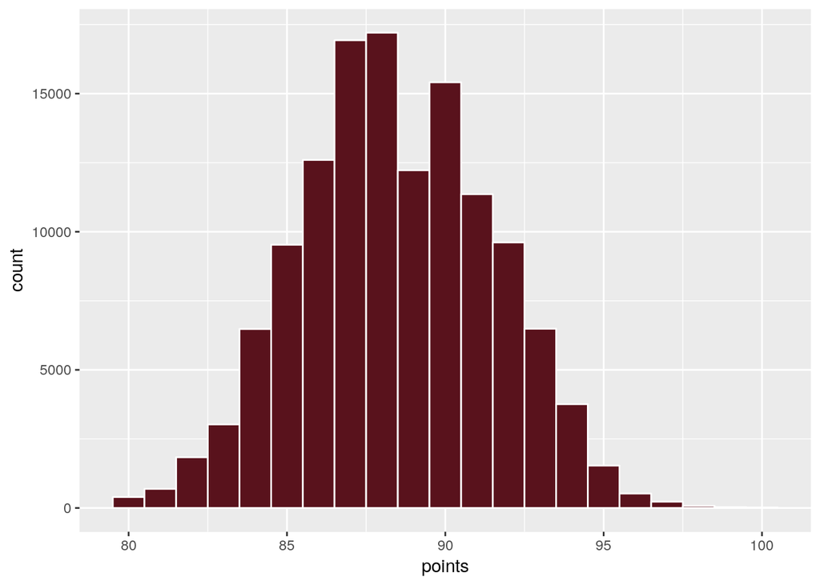

```r
wine_colours %>% ggplot(aes(x = points)) +
    geom_histogram(
        bins = nrow(wine %>% distinct(points)),
        colour = "white",
        fill = red_wine_colour
    )
```

## Text analysis

Each wine is accompanied by a single-paragraph review. Using the tidytext package we can investigate word and n-gram frequency of these reviews. We first break down the review into single words.

```r
wine_words <- wine %>%
    unnest_tokens(word, description) %>%
    anti_join(stop_words, by = "word") %>%
    filter(word != "wine")
```

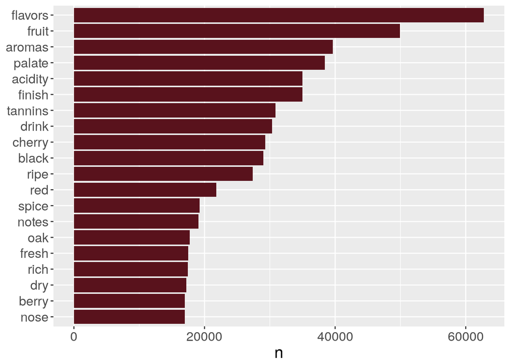

```r
wine_words %>%
    count(word, sort = TRUE) %>%
    head(20) %>%
    mutate(word = reorder(word, n)) %>%
    ggplot(aes(word, n)) +
    geom_col(fill = red_wine_colour) +
    xlab(NULL) +
    theme(text = element_text(size=16)) +
    coord_flip()
```

I’m not sure what purpose word clouds serve, but they seem mandatory at this point.

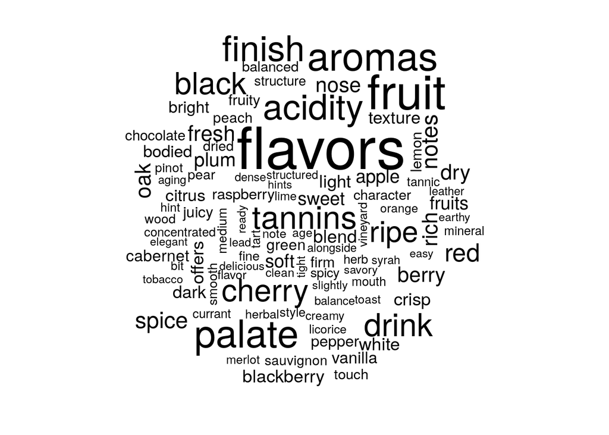

```r
wine_words %>%
  count(word) %>%
  with(wordcloud(word, n, max.words = 100))
```

An n-gram is a tuple of words appearing sequentially in order within an utterance. For example, in the utterance “My name is Fred”, “is Fred” is a 2-gram and “name is Fred” is a 3-gram. A word could also be considered as a 1-gram. Below we define the 2-grams (bigrams) and 3-grams (trigrams) of the wine descriptions.

Along with the `ngram` column, the `separate` column provides us with separate columns for each word in the n-gram. The column names for these words are dynamically generated in the `wine_ngrams` helper function, which provides outputs a tibble of n-grams for a given n. We then use these new word columns to filter out the stop words, although this time we include n-grams with the word “wine”.

```r
wine_ngrams <- function(n) {
    wine %>%
        unnest_tokens(ngram, description, token = "ngrams", n = n) %>%
        separate(
            ngram,
            sapply(1:n, function(x) {paste0("word", x)}), # eg, "word1", "word2"
            sep = " ",
            remove = FALSE # keep the n-gram in the tibble
        )
}

wine_2grams <- wine_ngrams(2) %>%
    filter(!word1 %in% stop_words$word) %>%
    filter(!word2 %in% stop_words$word)
wine_3grams <- wine_ngrams(3) %>%
    filter(!word1 %in% stop_words$word) %>%
    filter(!word2 %in% stop_words$word) %>%
    filter(!word3 %in% stop_words$word)
```

There are 1436412 2-grams, taking up around 201 megabytes of memory, and 649539 3-grams, taking up around 122 megabytes. The drop in number and size is due to the filtering of the stop words.

We can also plot the frequency of the 2- and 3-grams:

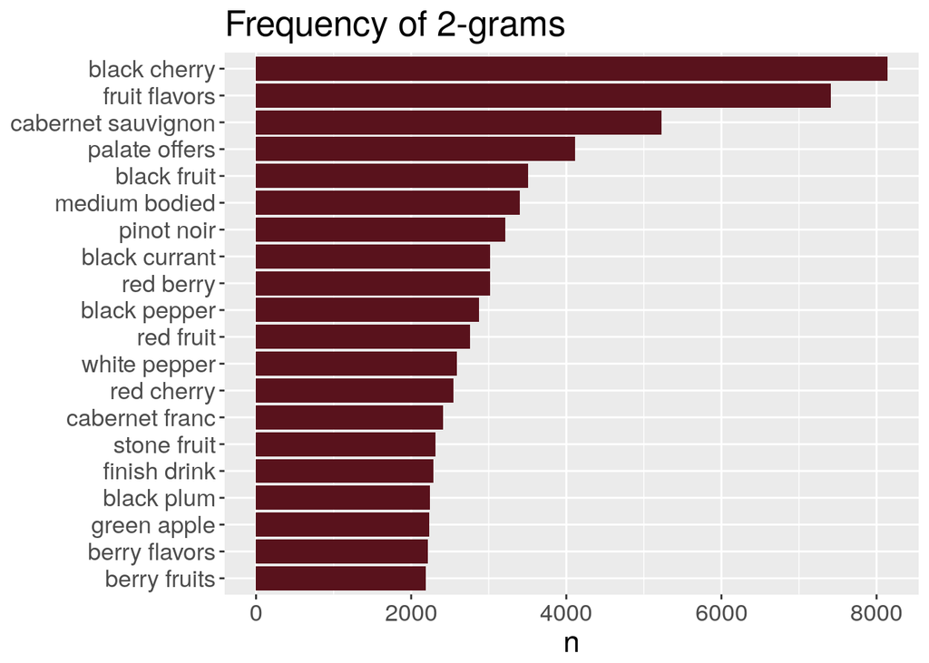

```r
plot_ngram_frequency <- function(x) {
    get(paste0("wine_", x, "grams")) %>%
        count(ngram, sort = TRUE) %>%
        head(20) %>%
        mutate(ngram = reorder(ngram, n)) %>%
        ggplot(aes(ngram, n)) +
        geom_col(fill = red_wine_colour) +
        xlab(NULL) +
        theme(text = element_text(size=16)) +
        coord_flip() +
        ggtitle(paste0("Frequency of ", x, "-grams"))
}

plot_ngram_frequency(2)
```

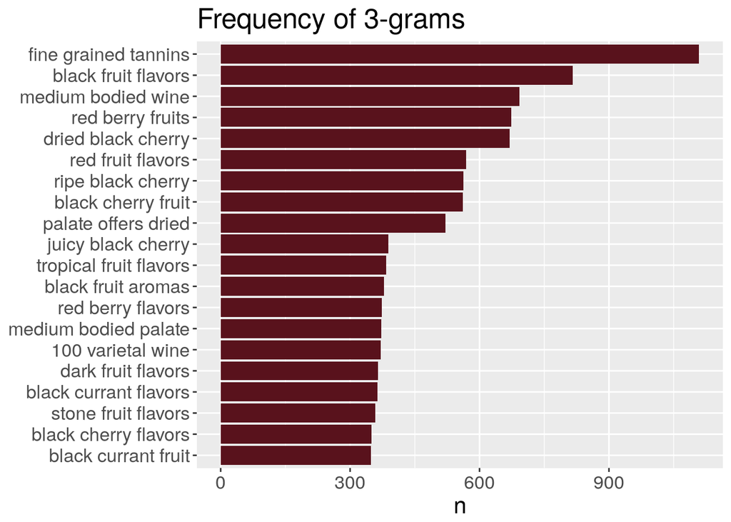

```r
plot_ngram_frequency(3)
```